# Assigment 2

Gabriele Stella

6/04/2022

[figure not shown]

**How I Met Your Mother** (often abbreviated as **HIMYM**) is an American sitcom, created by *Craig Thomas* and *Carter Bays* for CBS. The series, which aired from 2005 to 2014, follows the main character, *Ted Mosby*, and his group of friends in New York City’s Manhattan. As a framing device, *Ted*, in the year 2030, recounts to his son, *Luke*, and daughter, *Penny*, the events from September 2005 to May 2013 that led him to meet their mother. How I Met Your Mother is a joint production by Bays & Thomas Productions and 20th Television and syndicated by 20th Television (now Disney-ABC Domestic Television).

### basic statistics about seasons

| Season | Period | Viewers (mln) | Rating |
| --- | --- | --- | --- |
| 1 | 09/05 - 05/06 | 9.47 | 3.2 |
| 2 | 09/06 - 05/07 | 8.94 | 4.67 |
| 3 | 09/07 - 05/08 | 8.21 | 4.5 |
| 4 | 09/08 - 05/09 | 9.42 | 4.8 |
| 5 | 09/09 - 05/10 | 8.60 | 4.6 |
| 6 | 09/10 - 05/11 | 8.79 | 3.9 |
| 7 | 09/11 - 05/12 | 9.67 | 4.3 |
| 8 | 09/12 - 05/13 | 9.02 | 4.1 |
| 9 | 09/13 - 03/14 | 10.51 | 3.7 |

#### note

- *fourth* season was related as the best by fans, although the *ninth* had the most *viewers*
- each *season* took about *eight month* to be shot

## graphics

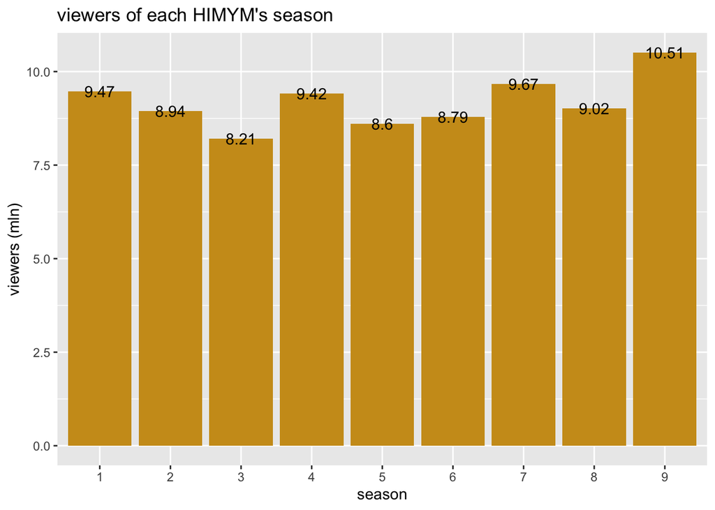

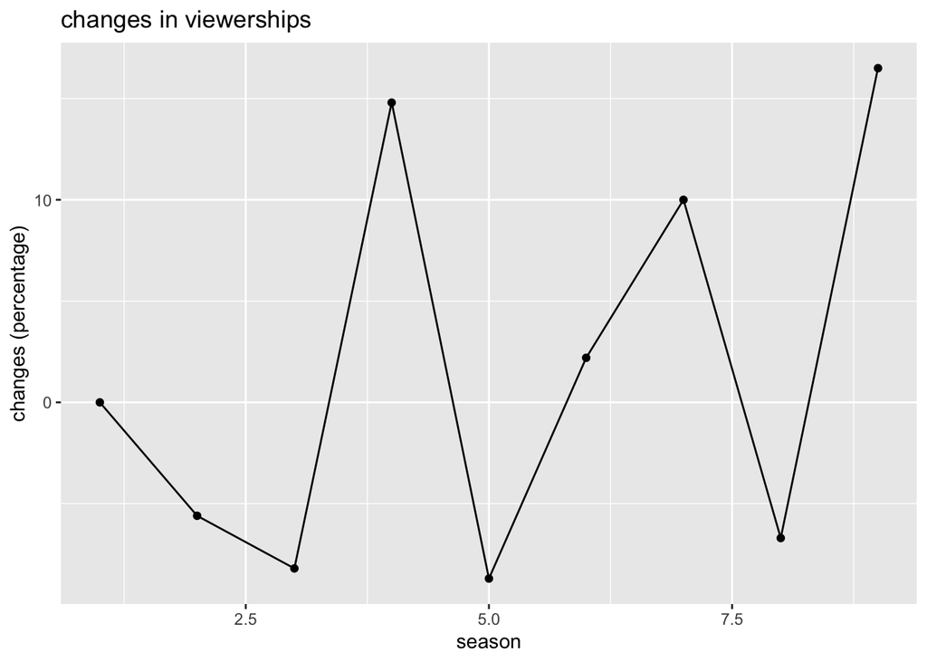

#### conclusion

as we can see there are no evidence of a trend during the time.

##### anyway we can note that:

- the season with more viewers is the season 9 with 10.51 milion viewers.
- the least watched season was season 3 with 8.21 milion viewers;
- the more and the least watched season has a different of exactly 2.3 milion viewers